# Alec Jones Honours Thesis Code

Alec Jones

26 March, 2025

# Loading in and cleaning the Reef Life Survey Data from Barkley Sound, BC, Canada, in 2024

## Loading in the 2024 data

```
## ──────────────────────────────────────────────────────── Delimiter: "," chr
## (12): Diver, Buddy, Site No., Site Name, Date, Direction, P-Qs, Method,... dbl
## (35): ID, Latitude, Longitude, vis, Depth, Total, Inverts, 2.5, 5, 7.5,... lgl
## (20): ...49, ...50, ...51, ...52, ...53, ...54, ...55, ...56, ...57, ..... time
## (1): Time
```

## Cleaning up the data

```r
#Making a list of the variables that I want to convert to factors in the step
#below
factor_cols2 <- c("site_code", "site_name", "Code")

#This pipe is taking the original raw dataframe and cleaning it up and storing
#it as a cleaned dataframe
RLS_data_2024_clean <- RLS_data_2024%>%
  #Picking which columns I want to keep
  select(c(`Site No.`, `Site Name`, Latitude, Longitude, Date, vis, Time, Depth,
           Method, Block, Code, Species, Total))%>%
  #Removing columns/rows with N/As
  na.omit()%>%
  #Changing all of the species codes to be lowercase as there were some of the
  #same species with codes differing by one or two capitals
  mutate(Code = str_to_lower(Code))%>%
  #Renaming the variables to be easier to code with
  rename(site_code = `Site No.`,
         site_name = `Site Name`,
         latitude = Latitude,
         longitude = Longitude,
         survey_date = Date,
         depth = Depth,
         visibility = vis,
         hour = Time,
         total = Total)%>%
  #Changing the variables that I specified earlier to be factors
   mutate_at(factor_cols2, factor)%>%
  #One point at the Kirby Site had the latitude value for both latitude and
  #longitude columns so this is fixing that
   mutate(longitude = if_else(site_code == "BMSC2", -125.19876860, longitude))%>%
  #In the dataset there are codes and counts of non-organisms (ex. dec = Debris
  # cloth). This is removing all the non-organisms from the dataset
  filter(!Code %in% c("dez", "deg", "dem", "deo", "def", "dew", "dec", "nsf", "snd"))%>%
  #This is grouping the data down to the species code within each individual
  #transect
   group_by(site_code, site_name, latitude, longitude, survey_date, depth,
           visibility, hour, Code)%>%
  #This is summing all of each species spotted at each transect. Ex. adding up
  #all red sea urchins at the Wouwer channel site
  summarise(species_total = sum(total))
```

[output not shown]

## Making a dataframe with the species of interest and ratios of interest

I made a dataframe with the counts of red turban snails and red sea urchins, along wih the log ratios of the two species to each other.

```r
#Starting pipe by taking data from the clean df I made
 urch_sn_ratio_mod_2024 <- RLS_data_2024_clean%>%
  #This makes a column for each species with the numbers of each in each
  #transect (each row)
  pivot_wider(names_from = Code, values_from = species_total)%>%
  #Renaming red sea urchin and red turban snail columns
  mutate(Urchins = mfra,
         Turban_Snails = pgi)%>%
  #Selecting only the columns I wanted and getting rid of the other species
  select(site_code, site_name, latitude, longitude, survey_date, depth,
           visibility, hour, Urchins, Turban_Snails)%>%
  #If urchins or snails were not counted at a site they were N/A at this stage
  #so this changes those counts to 0
  replace(is.na(.), 0)%>%
  #This calculates the ratios between species and makes a column for each. Date
  #is also converted to day month year form
  mutate(urch_sn_ratio = log10((Urchins +1) / (Turban_Snails + 1)),
         sn_urch_ratio = log10((Turban_Snails + 1) / (Urchins + 1)),
         urchin_dens = (Urchins / 100),
         snail_dens = (Turban_Snails / 100),
         survey_date = dmy(survey_date))
```

# Working with the potential predictor variables

For my project I incorporated various different predictor variables, some that I obtained from csv files and some that needed to be downloaded from online databases.

## Predictor 1: Wave exposure (via metric called Openness)

To get a measure of wave exposure for each of the RLS sites, I used a metric called openness from Hill et al. (2010)(10.3354/meps08815).

### Set up prior to calculating fetch for openness

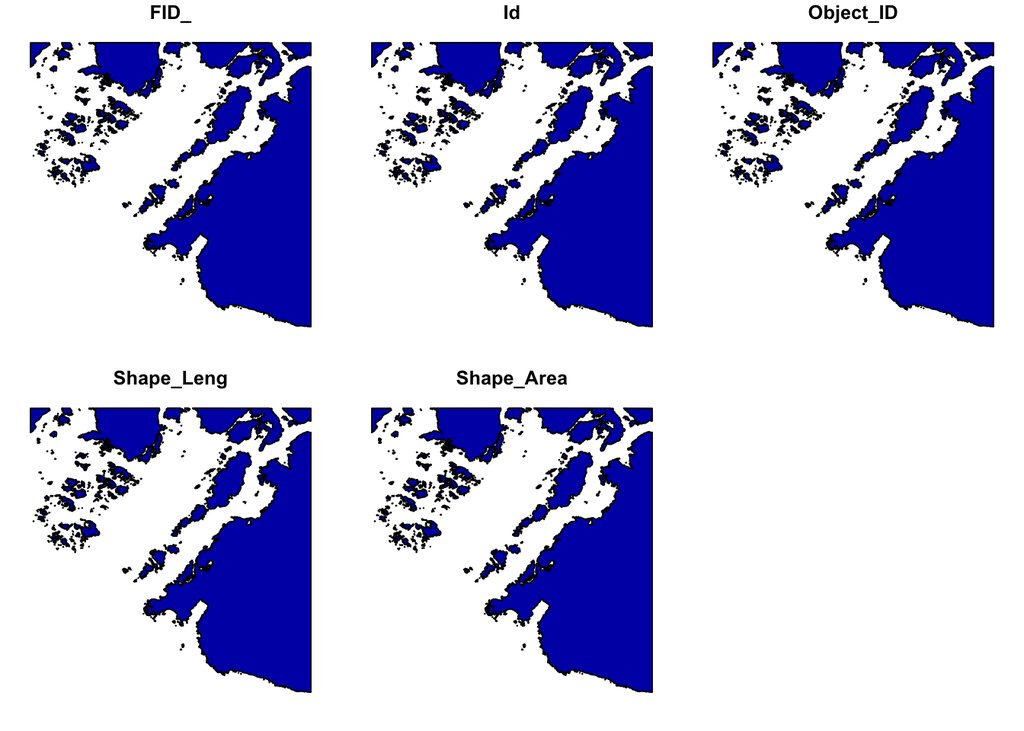

```r
#This subsets the shape file to only be of Barkley Sound to make plotting more
#efficient

#This makes coordinate limits to subset the shapefile
shp_xmin <- -125.4
shp_xmax <- -124.95
shp_ymin <- 48.7
shp_ymax <- 49.0

#This makes a bounding of the coordinates that I just made
bbox <- st_bbox(c(xmin = shp_xmin, ymin = shp_ymin, xmax = shp_xmax, ymax = shp_ymax))

#This converts the boundary box to an SFC object
bbox_sf <- st_as_sfc(bbox)

#This crops the shape file to the area of the bounding box
VI_base_layer_hi_res_sf_subset <- st_crop(VI_base_layer_hi_res_sf, bbox_sf)
plot(VI_base_layer_hi_res_sf_subset)
```

### Calculating the fetch for the sites

```r
#Makes an object of all the bearings to calculate fetch along
bearings_openness <- seq(7.5, 360, by = 7.5)

#Specifies to use the GEOS engine
sf::sf_use_s2(FALSE)

#This calculates the fetch for each site along each of the bearings calculated
#above. Max possible fetch is 650,000 meters. It is using the shape file from
#above to know where land is. This will likely take a very long time to run
#so do not worry.
fetch_df_2024_openness <- fetch_len_multi(site_sp_2024,
                                          bearings = bearings_openness,
                                          dmax = 650000,
                                          shoreline = VI_base_layer_hi_res_sf,
                                          projected = FALSE)

#Converting the raw fetch data into a df
fetch_df_2024_openness <- as.data.frame(fetch_df_2024_openness)

#Saving the fetch data to a .csv so that the fetch function does not need to be
#run
write_csv(fetch_df_2024_openness, here("./01_raw_data/fetch_df_2024_openness.csv"))
```

### Downloading the fetch data that is already saved

```r
fetch_df_2024_openness <- read_csv(here("./01_raw_data/fetch_df_2024_openness.csv"))
```

### Turning the raw fetch data into a dataframe with column labels

```r
#Making an object with all of the site code names listed to be able to make a
#column of site codes in the fetch df below
site_code <- c("BMSC1", "BMSC10", "BMSC11", "BMSC12", "BMSC13", "BMSC14", "BMSC15", "BMSC16",
               "BMSC17", "BMSC18", "BMSC19", "BMSC2", "BMSC20", "BMSC21", "BMSC22", "BMSC23", "BMSC24",
               "BMSC25", "BMSC26", "BMSC27", "BMSC3", "BMSC4", "BMSC5", "BMSC6", "BMSC8", "BMSC9")

#Adding a column with the site codes
fetch_df_2024_openness$site_code <- site_code
#Adding a column with the site lat
fetch_df_2024_openness$latitude <- site_coords_2024$latitude
#Adding a column with the site long
fetch_df_2024_openness$longitude <- site_coords_2024$longitude

#Reorganizing the order of the columns so that site code, lat, and long are
#first
fetch_df_2024_openness_final <- fetch_df_2024_openness[, c(49, 50, 51, seq(1, 48, by = 1))]

#Converting into long format for further analysis and adding to the RLS data
fetch_df_2024_openness_long <- fetch_df_2024_openness_final%>%
  #Makes column with bearing degree and column with corresponding fetch
  pivot_longer(cols = `7.5`: `360`,
               names_to = "degree",
               values_to = "fetch",
               #Removes the prefix "degree" from the values going into the
               #degree column
               names_prefix = "degree")
```

## Predictor 2: Mean SST

To get a measure of temperature I downloaded daily satellite sst data from the Copernicus Marine product for the year before the sampling in Barkley Sound occurred.

### Loading in the temperature data and calculating the average SST

```r
average_temperature <- calc(temp_2023_2024, fun = mean, na.rm = TRUE)

writeRaster(average_temperature,
            here("./01_raw_data/average_temperature.nc"),
            format = "CDF",
            overwrite = TRUE)
```

## Predictor 3: Protection from fishing status

In order to use the site protection status as a predictor, we needed to find support for the fact that there was in fact a difference in the human impacts between protected and unprotected sites.

To do this we used DFO flyover survey data that included the positions of where recreational fishing boats were located in Barkley Sound.

We used the DFO flyover counts of recreational boats actively fishing to calculate the annual mean number of recreational boats fishing within a given radius of each site to support the site protection status classifications and show that human impacts were higher for unprotected sites. To calculate the annual mean number of recreational boats fishing within a given radius of each site, we constructed circular polygons around each site (radii = 1 km, 1.5 km, 2 km) using R (R Core Team, 2024). We merged these polygons with the DFO recreational boat counts to extract how many boats were spotted within the radius in each year. To get the annual mean, we averaged these counts across the three years of data from DFO (2021, 2022, 2023). We omitted aerial surveys where parts of Barkley Sound were obscured by fog.

### Loading in the DFO survey data

#### Loading in the 2023 data

```r
DFO_data_raw_2023 <- read_csv(here("./01_raw_data/DFO_data/Overflight2023_ObservationPoints_20241024.csv"))
```

```
## ──────────────────────────────────────────────────────── Delimiter: "," chr
## (20): UniqueID, Filename/FlightID, Critical Period, Day Type, Creel Sub... dbl
## (5): Year, Month, Day, Latitude, Longitude lgl (1): ...27 date (1): Date
```

```r
#Makes list of the variables that need to be converted to factors below
dfo_factors <- c("Day Type", "Creel Subarea")

#takes the raw data and cleans it up
rec_boats_fishing2023 <- DFO_data_raw_2023%>%
  #converts the variables specified above to factors
  mutate_at(dfo_factors, factor)%>%
  #renaming the columns to make them easier to code with
  rename(rec_boats_fishing = `1. Rec Boat Fishing`,
         rec_boats_running = `2. Rec Boats Running`,
         comm_vessel_fishing = `3. Commercial Vessel Fishing`,
         comm_vessel_not_fishing = `4. Commercial Vessel Not Fishing`,
         small_comm_vessel = `5. Small Commercial Vessel`,
         large_comm_vessel = `6. Large Commercial Vessel`,
         whale_watching = `7.  Whale Watching Boat`,
         orcas = `8. Orcas`,
         whales = `9. Whales`,
         sea_state = `10. Sea State`)%>%
  #Replacing the cells that have "Null" with 0 and converting the count columns
  #to numeric
  mutate(across(c("rec_boats_fishing", "rec_boats_running", "comm_vessel_fishing",
                  "comm_vessel_not_fishing", "small_comm_vessel", "large_comm_vessel",
                  "whale_watching", "orcas", "whales"), ~ ifelse(. == "<Null>", 0, .)),
         across(c("rec_boats_fishing", "rec_boats_running", "comm_vessel_fishing",
                  "comm_vessel_not_fishing", "small_comm_vessel", "large_comm_vessel",
                  "whale_watching", "orcas", "whales"), as.numeric))%>%
  ##This code will remove the dates of the flights that had fog
  filter(!Date %in% c("2023-06-23", "2023-07-16", "2023-07-31", "2023-08-06", "2023-08-28",
                      "2023-08-29", "2023-09-09", "2023-09-15"))%>%
  #Selecting only the rows where recreational boats were fishing
  filter(rec_boats_fishing != 0)%>%
  #selecting all of the columns that are needed for further analysis
    select(c(UniqueID, `Filename/FlightID`, Year, Month, Day, Date, `Critical Period`, `Day Type`, `Creel Subarea`, GMA, PFMA,
           `Pin ID`, Longitude, Latitude, rec_boats_fishing, rec_boats_running))
```

#### Loading in the 2022 data

```r
DFO_data_raw_2022 <- read_csv(here("./01_raw_data/DFO_data/Overflight2022_ObservationPoints_20240124_COUNTS.csv"))
```

```
## ──────────────────────────────────────────────────────── Delimiter: "," chr
## (19): UniqueID, Filename/FlightID, Critical Period, Day Type, Creel Sub... dbl
## (6): Year, Month, Day, Latitude, Longitude, Count (1/2) lgl (1): ...28 dttm
## (1): Date Created (Timestamp from Avenza Maps) date (1): Date
```

```r
#dfo_factors <- c("Day Type", "Creel Subarea")

rec_boats_fishing2022 <- DFO_data_raw_2022%>%
  mutate_at(dfo_factors, factor)%>%
  rename(rec_boats_fishing = `1. Rec Boat Fishing`,
         rec_boats_running = `2. Rec Boats Running`,
         comm_vessel_fishing = `3. Commercial Vessel Fishing`,
         comm_vessel_not_fishing = `4. Commercial Vessel Not Fishing`,
         small_comm_vessel = `5. Small Commercial Vessel`,
         large_comm_vessel = `6. Large Commercial Vessel`,
         whale_watching = `7.  Whale Watching Boat`,
         orcas = `8. Orcas`,
         whales = `9. Whales`,
         sea_state = `10. Sea State`)%>%
  mutate(across(c("rec_boats_fishing", "rec_boats_running", "comm_vessel_fishing",
                  "comm_vessel_not_fishing", "small_comm_vessel", "large_comm_vessel",
                  "whale_watching", "orcas", "whales"), ~ ifelse(. == "<Null>", 0, .)),
         across(c("rec_boats_fishing", "rec_boats_running", "comm_vessel_fishing",
                  "comm_vessel_not_fishing", "small_comm_vessel", "large_comm_vessel",
                  "whale_watching", "orcas", "whales"), as.numeric))%>%
   ##This code will remove the dates of the flights that had fog
  filter(!Date %in% c("2022-06-18", "2022-07-31", "2022-08-24", "2022-06-04"))%>%
    filter(rec_boats_fishing != 0)%>%
  #selecting all of the columns that are needed for further analysis
    select(c(UniqueID, `Filename/FlightID`, Year, Month, Day, Date, `Critical Period`, `Day Type`, `Creel Subarea`, GMA, PFMA,
           `Pin ID`, Longitude, Latitude, rec_boats_fishing, rec_boats_running))
```

#### Loading in the 2021 data

```r
DFO_data_raw_2021 <- read_csv(here("./01_raw_data/DFO_data/Overflight2021_ObservationPoints_20240321_counts.csv"))
```

[output not shown]

```r
#dfo_factors <- c("Day Type", "Creel Subarea")

rec_boats_fishing2021 <- DFO_data_raw_2021%>%
  mutate_at(dfo_factors, factor)%>%
  rename(rec_boats_fishing = `1. Rec Boat Fishing`,
         rec_boats_running = `2. Rec Boats Running`,
         comm_vessel_fishing = `3. Commercial Vessel Fishing`,
         comm_vessel_not_fishing = `4. Commercial Vessel Not Fishing`,
         small_comm_vessel = `5. Small Commercial Vessel`,
         large_comm_vessel = `6. Large Commercial Vessel`,
         whale_watching = `7.  Whale Watching Boat`,
         orcas = `8. Orcas`,
         whales = `9. Whales`,
         sea_state = `10. Sea State`)%>%
  mutate(across(c("rec_boats_fishing", "rec_boats_running", "comm_vessel_fishing",
                  "comm_vessel_not_fishing", "small_comm_vessel", "large_comm_vessel",
                  "whale_watching", "orcas", "whales"), ~ ifelse(. == "<Null>", 0, .)),
         across(c("rec_boats_fishing", "rec_boats_running", "comm_vessel_fishing",
                  "comm_vessel_not_fishing", "small_comm_vessel", "large_comm_vessel",
                  "whale_watching", "orcas", "whales"), as.numeric))%>%
   ##This code will remove the dates of the flights that had fog
  filter(!Date %in% c("2021-07-31", "2021-07-19", "2021-07-20", "2021-07-24"))%>%
   filter(rec_boats_fishing != 0)%>%
  select(c(UniqueID, `Filename/FlightID`, Year, Month, Day, Date, `Critical Period`, `Day Type`, `Creel Subarea`, GMA, PFMA,
           `Pin ID`, Longitude, Latitude, rec_boats_fishing, rec_boats_running))
```

#### Combining the three years of data into one data frame

```r
rec_boats_fishing_total <- rbind(rec_boats_fishing2021, rec_boats_fishing2022, rec_boats_fishing2023)
```

#### Making a preliminary plot to see if it worked

```r
#first need to specify the range of the map
lat_min = min(RLS_data_2024_clean$latitude) - 0.05
lat_max = max(RLS_data_2024_clean$latitude) + 0.05

long_min = min(RLS_data_2024_clean$longitude) - 0.05
long_max = max(RLS_data_2024_clean$longitude) + 0.05
```

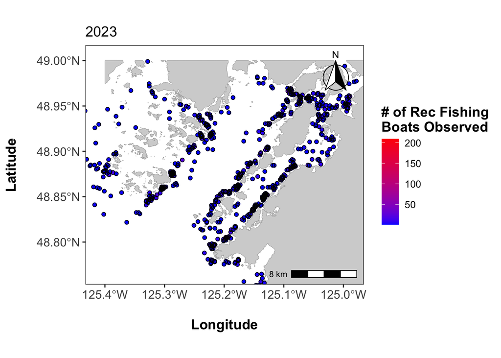

```r
 ggplot()+
    geom_sf(data = VI_base_layer_hi_res_sf_subset, colour = "darkgrey", fill = "lightgrey")+
    coord_sf(xlim = c(long_min, long_max),
           ylim = c(lat_min, lat_max)) +
    geom_point(data = rec_boats_fishing2023,
             mapping = aes(x = Longitude, y = Latitude, color = rec_boats_fishing),
             size = 1.5,) +
    scale_colour_gradient(low = "blue", high = "red")+
   geom_point(data = rec_boats_fishing2023,
             mapping = aes(x = Longitude, y = Latitude, colour = rec_boats_fishing),
              shape = 1, size = 1.5, colour = "black") +
  labs(title = "2023", x = " \nLongitude", y = "Latitude\n ", colour = "# of Rec Fishing\nBoats Observed") +
  theme.figure() +
  annotation_north_arrow(
    location = "tr",
    which_north = "true",
    style = north_arrow_fancy_orienteering
  ) +
  annotation_scale(location = "br")
```

# Adding the predictors to a dataframe for modelling

## Adding the temperature data

```r
#This pipe makes a df with the lat and long of all of the different sites
site_points_df <- urch_sn_ratio_mod_2024%>%
   ungroup()%>%
  select(longitude, latitude)

#This sets the long and lat as coordinates
coordinates(site_points_df) <- ~longitude+latitude

#This sets the projection of the site locations to be on the same projection
#as the average temperature raster
proj4string(site_points_df) <- crs(average_temperature)

#This extracts the average temperature for where each site is located and then
#subtracts the constant to convert from Kelvin to celsius
sst_values <- raster::extract(average_temperature, site_points_df) - 273.15

#Makes a column with the sst values in the modelling df
urch_sn_ratio_mod_2024$sst <- sst_values
```

## Adding the photoquadrat data

One of the predictors that I used was the dominant seafloor type of each transect. I did this by using photoquadrats and stored the data from my analysis in an Excel sheet. I saved this as a .csv and simply loaded this into R to use in the models.

### Loading in the photoquadrat data

```r
pq_data <- read_csv(here("./01_raw_data/pq_data.csv"))
#This specifies the only columns that I wanted for analysis abd
pq_data_final <- pq_data%>%
  select(c(site_code, depth, dominant_score, secondary_score))%>%
  #There were multiple rows for each site corresponding to each photoquadrat
  #so this made just one row for each site
  distinct(site_code, depth, .keep_all = TRUE)

#This merges the photoquadrat data with the modelling data based on the specific
#transects. The all.x specifies a left join.
urch_sn_ratio_mod_2024 <- merge(urch_sn_ratio_mod_2024, pq_data_final, by = c("site_code", "depth"),
                                all.x = TRUE)
```

## Adding the openness data

```r
#Calculates the openness of each site
openness <- fetch_df_2024_openness_long%>%
  #grouping by each site
  group_by(site_code, latitude, longitude)%>%
  #adding up all of the fetch vectors for each site
  summarise(openness = sum(fetch))
#identifying the largest openness score within the dataset
max_openness <- max(openness$openness)

#Making a column of normalized openness by dividing by the max observed openness
openness <- openness%>%
mutate(norm_openness = openness / max_openness)

#Merging the modelling df with the openness df by each site
urch_sn_ratio_mod_2024 <- merge(urch_sn_ratio_mod_2024, openness, by = c("site_code", "latitude", "longitude"))
```

## Adding the recreational fishing boat data

To add the recreational fishin boat data we first calculated the mean number of recreational fishing boats fishing within various radii of each RLS site. We did this by making circular polygons around each RLS site and then merging those with the rec boat points and counting how many were in each circle each year, and then averaging across the three years of data.

### Calculating the mean recreational boats fishing within each radius

```r
#Taking the site locations from the model
site_locations <- st_as_sf(urch_sn_ratio_mod_2024, coords = c("longitude", "latitude"), crs = 4326)

#Picking only the unique site locations as some sites have multiple transects
#with the same coordinates
site_locations_u <- site_locations%>%
  distinct(site_code, geometry)

#Changing the projection to handle meter distances better
site_locations_u_proj_m <- st_transform(site_locations_u, crs = 3857)
#Making circles with the different radii around each site
site_locations_radius_1km <- st_buffer(x = site_locations_u_proj_m, dist = 1000)
site_locations_radius_1.5km <- st_buffer(x = site_locations_u_proj_m, dist = 1500)
site_locations_radius_2km <- st_buffer(x = site_locations_u_proj_m, dist = 2000)
```

```r
#making a data frame with the coordinates of all the recreational fishing boats
rec_boats_fishing_total_points <- st_as_sf(rec_boats_fishing_total, coords = c("Longitude", "Latitude"), crs = 4326)
#Converting the CRS so it matches the other parts being used
rec_boats_fishing_total_points <- st_transform(rec_boats_fishing_total_points, crs = 3857)


#Finding the fishing boats that are within the given radius and making a new df
#with this info
rec_fishing_boat_total_radius_1km <- st_intersection(site_locations_radius_1km, rec_boats_fishing_total_points)
rec_fishing_boat_total_radius_1.5km <- st_intersection(site_locations_radius_1.5km, rec_boats_fishing_total_points)
rec_fishing_boat_total_radius_2km <- st_intersection(site_locations_radius_2km, rec_boats_fishing_total_points)
#Here I took the data frames with the counts and points of boats within the
#radii of the sites and I summed the number of boats counted around a site
#within each year. For example, I added all of the boats around Eagle bay in
#2021

rec_fishing_boat_total_radius_1km_summed <- rec_fishing_boat_total_radius_1km%>%
  #Grouping by each site in each year
  group_by(site_code, Year)%>%
  #adding up the number of boats around a site in each year
  summarise(yearly_rec_boats_fishing = sum(rec_boats_fishing))
rec_fishing_boat_total_radius_1.5km_summed <- rec_fishing_boat_total_radius_1.5km%>%
  group_by(site_code, Year)%>%
  summarise(yearly_rec_boats_fishing = sum(rec_boats_fishing))
rec_fishing_boat_total_radius_2km_summed <- rec_fishing_boat_total_radius_2km%>%
  group_by(site_code, Year)%>%
  summarise(yearly_rec_boats_fishing = sum(rec_boats_fishing))
#For some sites that had boats counted in one particular year at a given radius
#did not have counts in all years. This step made data frames with a list of all
#of the sites that had at least some counts at the given radius in one of the
#years and then made a row for each of the three years for that site.

#Makes a row for all three years for sites that had a least one boat counted
#in one of the years
all_sites_years_1km <- expand.grid(
  site_code = unique(rec_fishing_boat_total_radius_1km$site_code),
  Year = unique(rec_fishing_boat_total_radius_1km$Year))

all_sites_years_1.5km <- expand.grid(
  site_code = unique(rec_fishing_boat_total_radius_1.5km$site_code),
  Year = unique(rec_fishing_boat_total_radius_1.5km$Year))

all_sites_years_2km <- expand.grid(
  site_code = unique(rec_fishing_boat_total_radius_2km$site_code),
  Year = unique(rec_fishing_boat_total_radius_2km$Year))
```

```r
#This step merged the summed boat counts at each site with the dataframe that
# had all three years listed so that there was a row with 0 for the sites which
#did not have any counts in a particular year. This was necessary for making the
#average calculation accurate.

rec_fishing_boat_total_radius_1km_complete <- all_sites_years_1km %>%
  #Joins the rec fishing boat counts within radius to the df with all the years
  #for each site by site and year
  left_join(rec_fishing_boat_total_radius_1km_summed, by = c("site_code", "Year")) %>%
  #replaces the rows that have NAs with 0
  mutate(yearly_rec_boats_fishing = replace_na(yearly_rec_boats_fishing, 0))

rec_fishing_boat_total_radius_1.5km_complete <- all_sites_years_1.5km %>%
  left_join(rec_fishing_boat_total_radius_1.5km_summed, by = c("site_code", "Year")) %>%
  mutate(yearly_rec_boats_fishing = replace_na(yearly_rec_boats_fishing, 0))

rec_fishing_boat_total_radius_2km_complete <- all_sites_years_2km %>%
  left_join(rec_fishing_boat_total_radius_2km_summed, by = c("site_code", "Year")) %>%
  mutate(yearly_rec_boats_fishing = replace_na(yearly_rec_boats_fishing, 0))
```

```r
#This was the final step to average the recreational boat counts at each site
#across the three years of data


rec_fishing_boat_total_radius_1km_final <- rec_fishing_boat_total_radius_1km_complete%>%
  #groups by each site
  group_by(site_code)%>%
  #makes a new column with the mean number of boats counted within each sites
  #radius
  summarise(mean_rec_boat_counts_1km = mean(yearly_rec_boats_fishing))

rec_fishing_boat_total_radius_1.5km_final <- rec_fishing_boat_total_radius_1.5km_complete%>%
  group_by(site_code)%>%
  summarise(mean_rec_boat_counts_1.5km = mean(yearly_rec_boats_fishing))

rec_fishing_boat_total_radius_2km_final <- rec_fishing_boat_total_radius_2km_complete%>%
  group_by(site_code)%>%
  summarise(mean_rec_boat_counts_2km = mean(yearly_rec_boats_fishing))
```

### Adding the mean rec boat counts to the modelling data frame

```r
#This step added each of the data frames with the average rec boat counts
# to the modelling dataset. The resulting dataset has a column for avg
#rec boat counts for each radius distance
urch_sn_ratio_mod_2024 <- urch_sn_ratio_mod_2024%>%
 left_join(rec_fishing_boat_total_radius_1km_final, by = c("site_code"))%>%
 left_join(rec_fishing_boat_total_radius_1.5km_final, by = c("site_code"))%>%
  left_join(rec_fishing_boat_total_radius_2km_final, by = c("site_code"))%>%
  replace(is.na(.), 0)
```

## Adding the region classifications for use as a random/fixed effect

In order to use region as a potential random or fixed effect during modelling I made region classifications for the sites depending on which Island group/area they were in. I made a few different region classifications, but ultimately we went with the region1 classification because it made the most logical sense.

```r
urch_sn_ratio_mod_2024 <- urch_sn_ratio_mod_2024%>%
  #makes a column for the region and then depending if the site code is
  #specified it puts the given region names below
  mutate(region1 = case_when(
    site_code %in% c("BMSC1", "BMSC10", "BMSC11", "BMSC12", "BMSC19", "BMSC2", "BMSC20",
                     "BMSC21", "BMSC22", "BMSC23", "BMSC25", "BMSC3", "BMSC4", "BMSC5", "BMSC9") ~ "Deer group/Bamfield",
   site_code %in% c("BMSC13", "BMSC14", "BMSC15", "BMSC16", "BMSC17", "BMSC18") ~ "Broken Group",
    site_code %in% c("BMSC24", "BMSC6", "BMSC8") ~ "Deep Imperial Eagle Channel",
    site_code %in% c("BMSC26", "BMSC27") ~ "Sarita"
  ))%>%
   mutate(region2 = case_when(
    site_code %in% c("BMSC1", "BMSC10", "BMSC11", "BMSC12", "BMSC19", "BMSC2", "BMSC20",
                     "BMSC3",  "BMSC5") ~ "Deer group",
    site_code %in% c("BMSC21", "BMSC22", "BMSC23", "BMSC25", "BMSC4", "BMSC9") ~ "Bamfield",
   site_code %in% c("BMSC13", "BMSC14", "BMSC15", "BMSC16", "BMSC17", "BMSC18") ~ "Broken Group",
    site_code %in% c("BMSC24", "BMSC6", "BMSC8") ~ "Deep Imperial Eagle Channel",
    site_code %in% c("BMSC26", "BMSC27") ~ "Sarita"
  ))%>%
   mutate(region3 = case_when(
     site_code%in% c("BMSC19", "BMSC2", "BMSC20", "BMSC3", "BMSC24", "BMSC6", "BMSC8") ~ "Imperial Eagle",
    site_code %in% c("BMSC1", "BMSC10", "BMSC11", "BMSC12",
                     "BMSC21", "BMSC22", "BMSC23", "BMSC25", "BMSC26", "BMSC27",
                     "BMSC4", "BMSC5", "BMSC9") ~ "Trevor Channel",
   site_code %in% c("BMSC13", "BMSC14", "BMSC15", "BMSC16", "BMSC17", "BMSC18") ~ "Broken Group",
  ))%>%
  mutate(region4 = case_when(
    site_code %in% c("BMSC21", "BMSC22", "BMSC23", "BMSC25", "BMSC4", "BMSC9", "BMSC26", "BMSC27") ~ "Bamfield",
    site_code %in% c("BMSC13", "BMSC14", "BMSC15", "BMSC16", "BMSC17", "BMSC18") ~ "Broken Group",
    site_code %in% c("BMSC24", "BMSC6", "BMSC8") ~ "Deep Imperial Eagle Channel",
    site_code %in% c("BMSC1", "BMSC10", "BMSC11", "BMSC12", "BMSC19", "BMSC2", "BMSC20",
                     "BMSC3",  "BMSC5") ~ "Deer group"
  ))
```

## Writing the modelling data frame to a .csv for future use

```r
write_csv(urch_sn_ratio_mod_2024,
          here("./03_clean_data/urchin_snail_modelling_data.csv"))
```

# Doing modelling for the project

## Loading in the modelling data and cleaning it up

## Exploratory plots of the data

Making some exploratory plots of the predictors against the response variables (urchin dens, snail dens, snail to urchin ratio).

### The EVs against the snail density

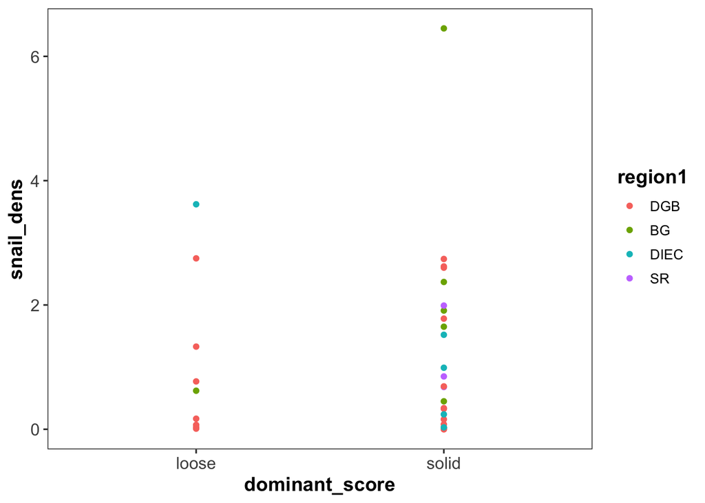

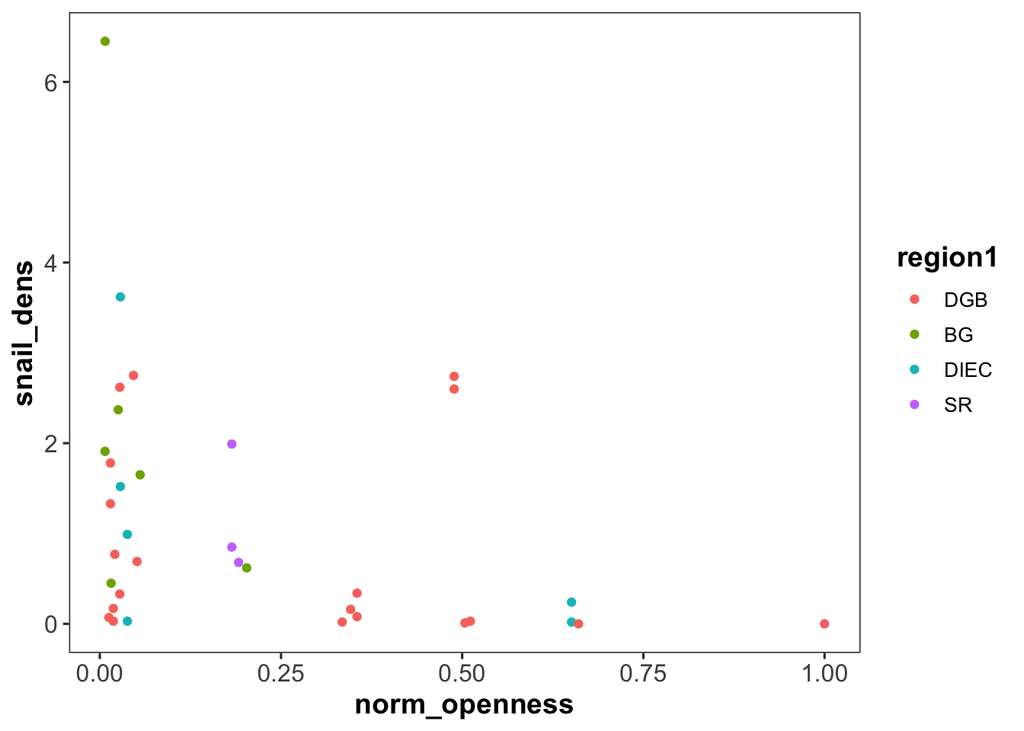

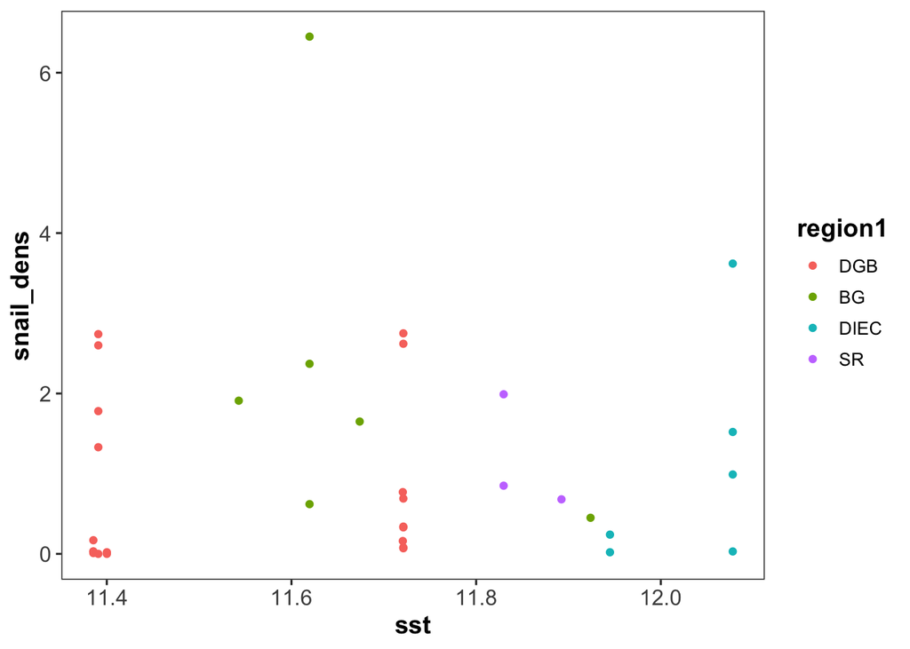

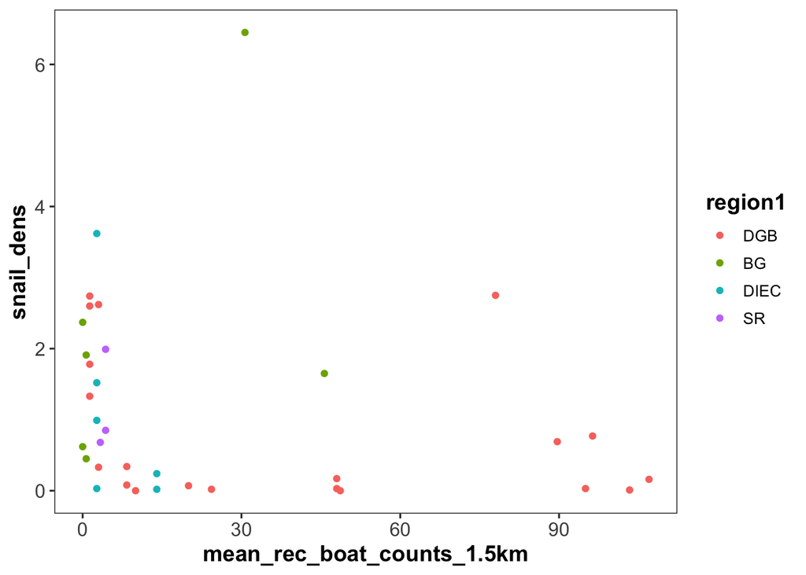

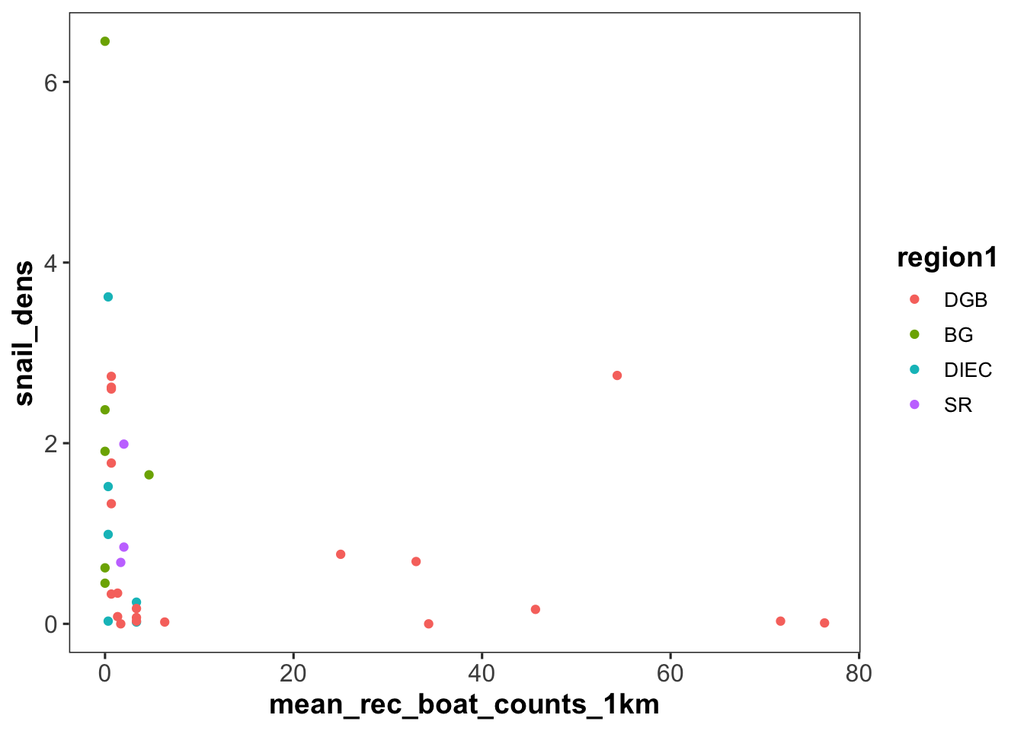

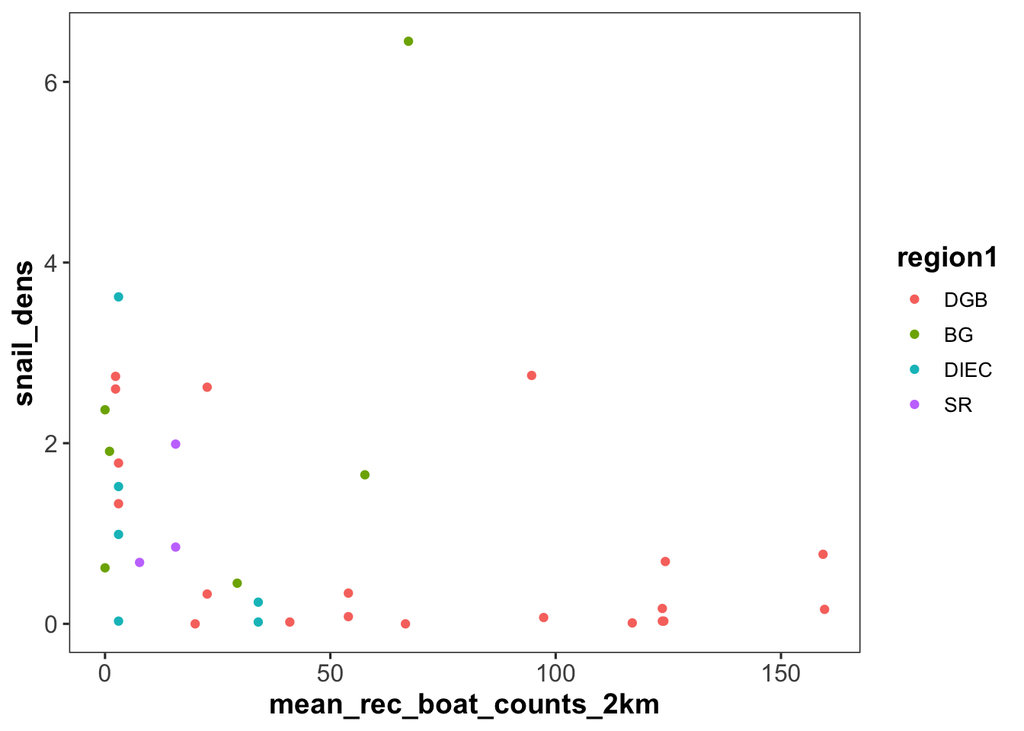

### The EVs against the urchin density

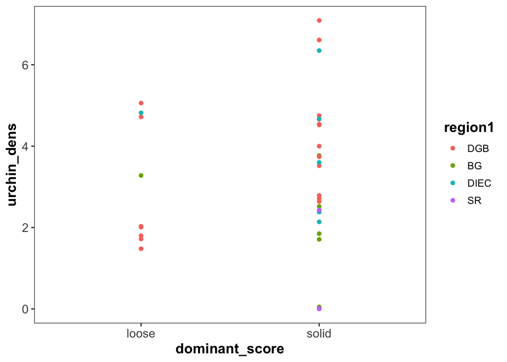

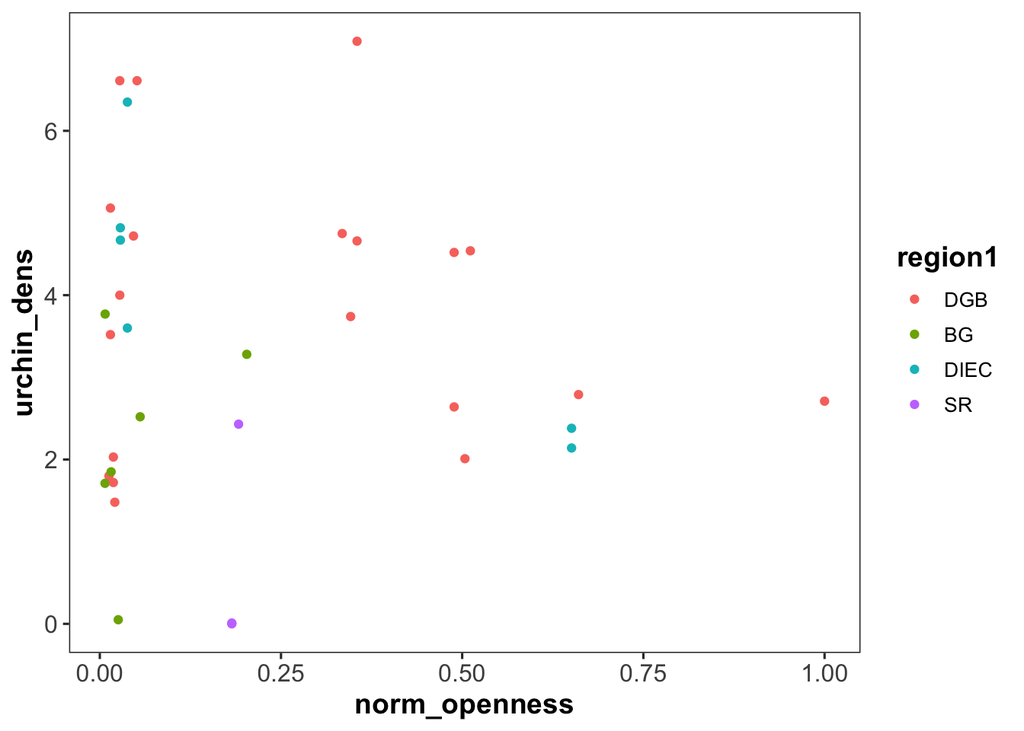

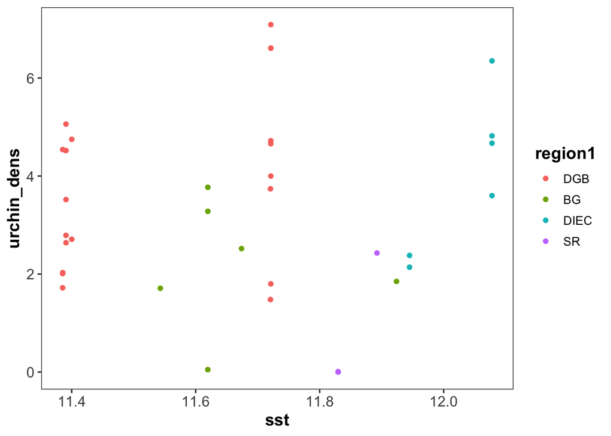

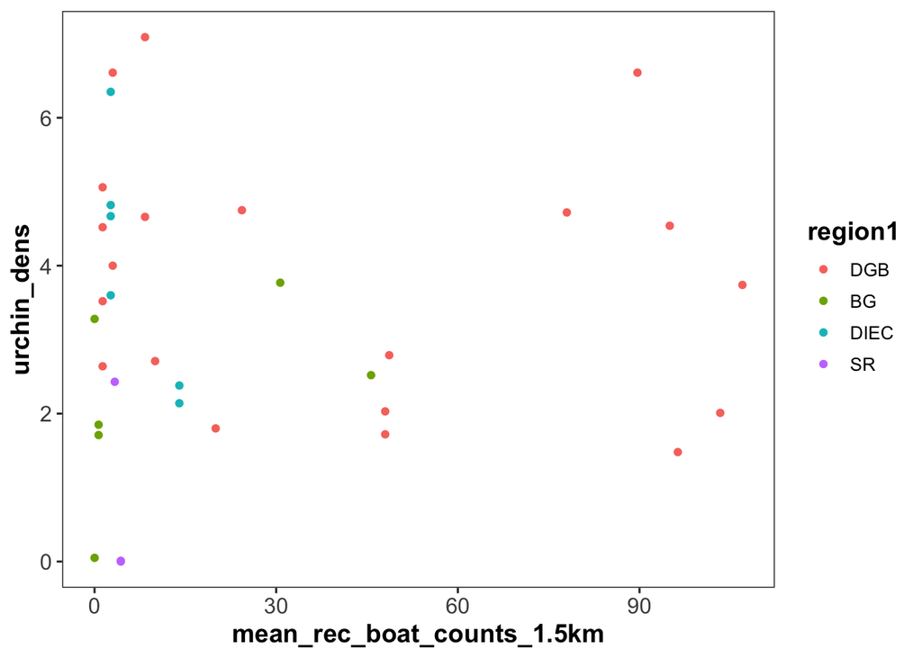

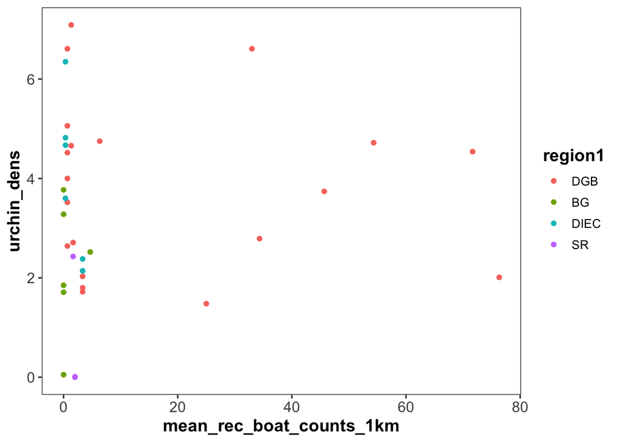

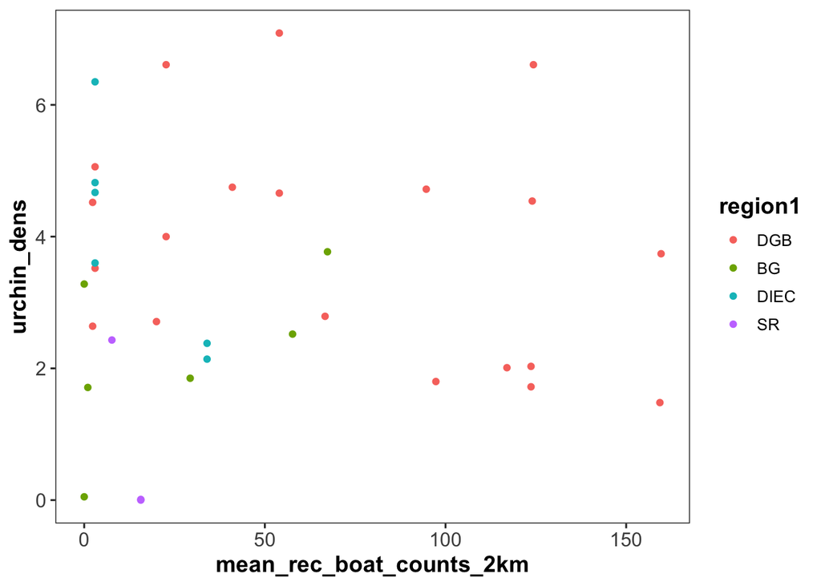

### The EVs against the snail to urchin ratio

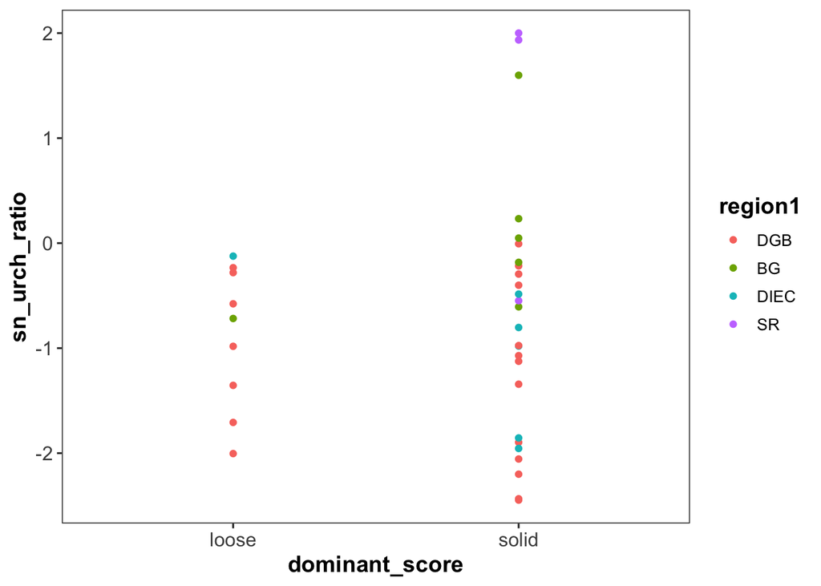

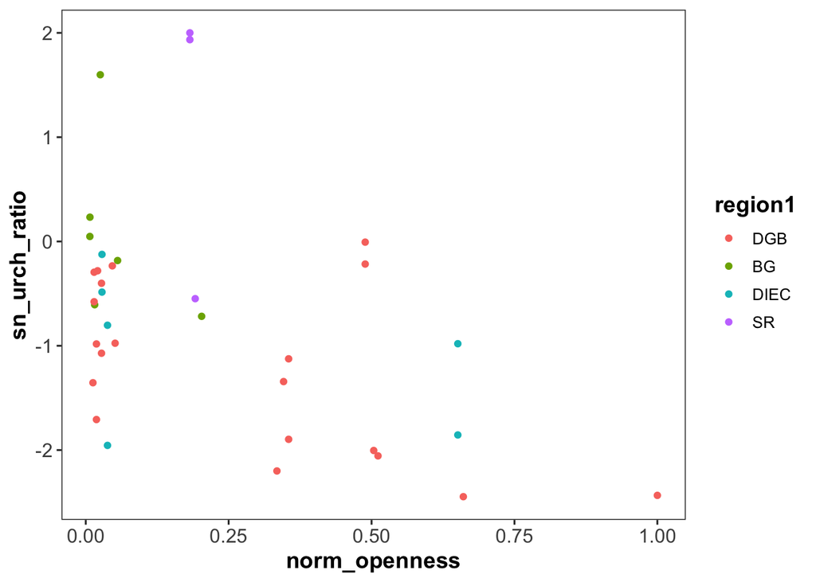

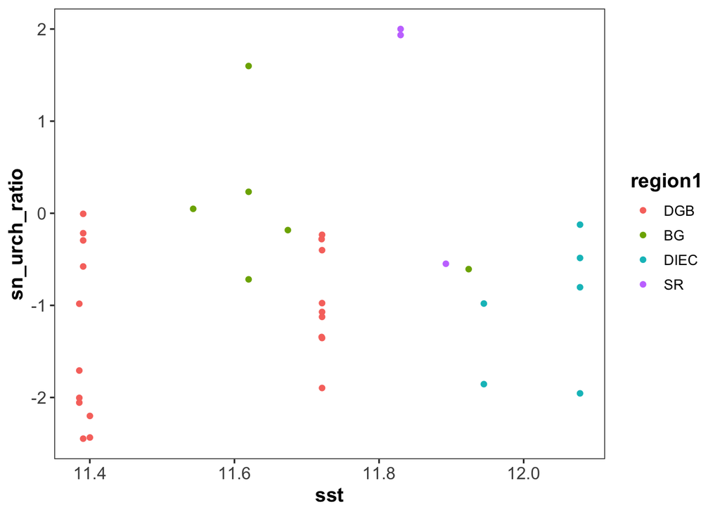

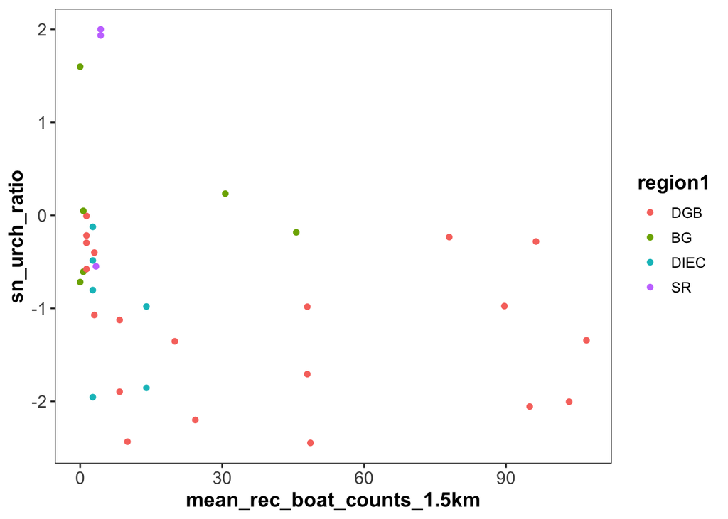

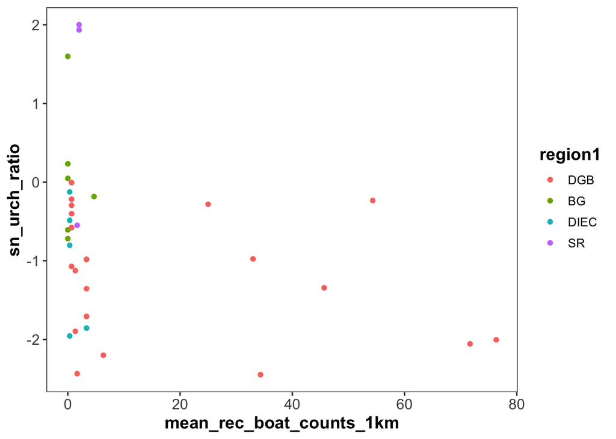

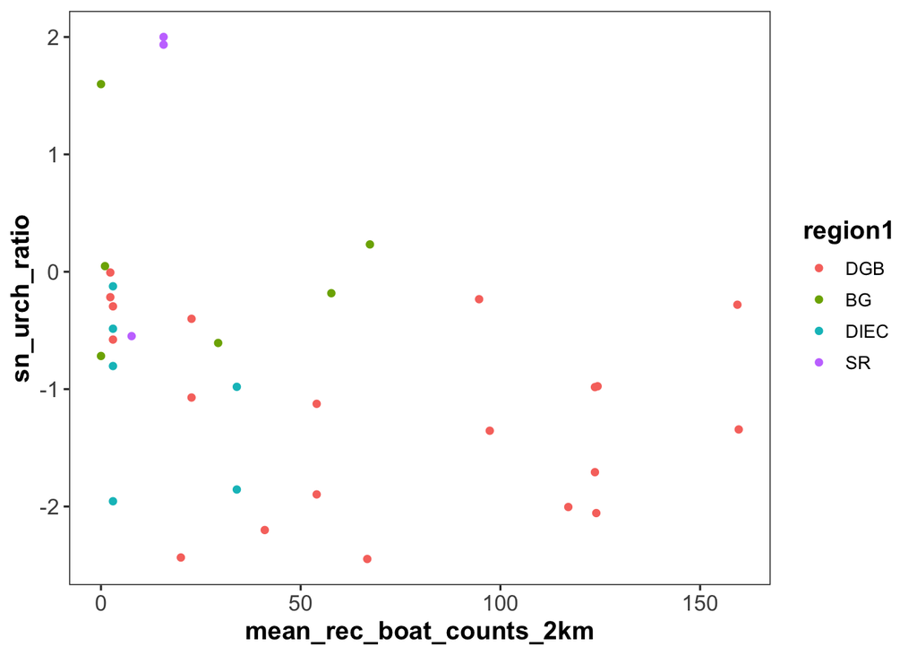

## Ecological models

The first set of models that we tried were generalized additive models to test the ecological predictors on the densities of each species to see what is driving their populations.

### Red Turban Snail Ecology models

We started with the turban snail models.

#### Model 1: Ecology model on the snail density with temperature, openness, and bottom type

```r
#We initially tested this model with the untransformed snail density, but the
#residuals were not good. We could not use Poisson or Negative binomial as there
#were decimals. We tried Gamma with adding a small constant to get rid of the 0s
#but this did not work well. Also tried Tweedie and scat but again did not look
#good. At this point we decided to log transform
#the snail density. We needed to add a constant to the density because there
#were some zeroes so we instead of adding 1, we added 0.01 because the snail
#densities were the snail counts divided by 100.
ecology_snail_mod <- gam(log(snail_dens + 0.01) ~ s(sst_scale)+
                               s(norm_openness_scale)+
                           dominant_score,
                             data = env_mod_data_hon,
                             family = gaussian(link = "identity"),
                         #we picked REML for smoothing parameter estimation as
                         #this is considered to be one of the best methods
                             method = "REML",
                         #we set select to TRUE meaning that the model can fully
                         #penalize smooth terms to zero effect if that is what
                         #is suggested
                             select = TRUE)
```

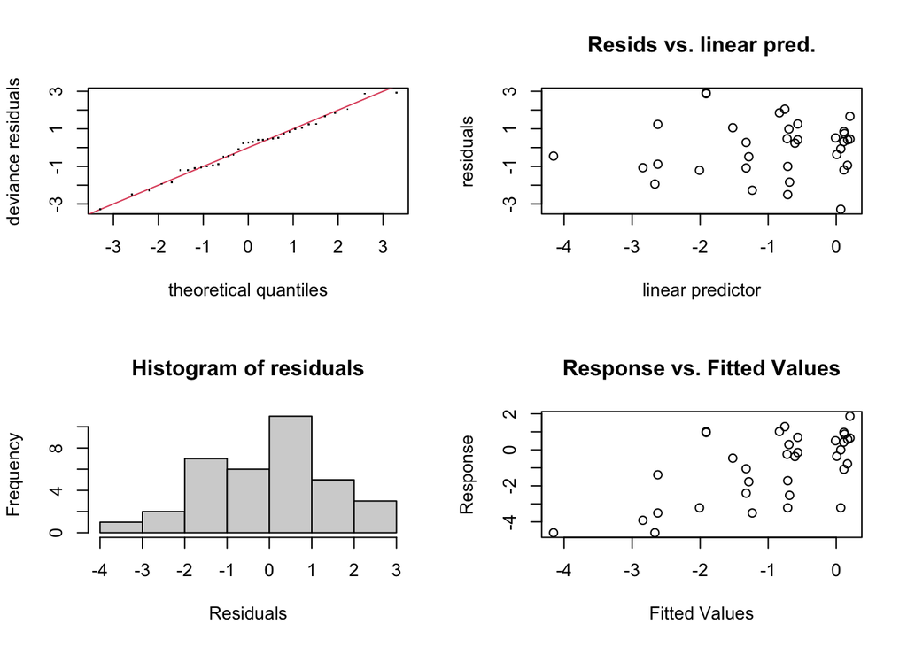

```
##
## Method: REML   Optimizer: outer newton
## full convergence after 12 iterations.
## Gradient range [-8.192637e-06,5.470485e-06]
## (score 64.57123 & scale 2.270256).
## Hessian positive definite, eigenvalue range [1.742853e-07,16.51402].
## Model rank =  20 / 20
##
## Basis dimension (k) checking results. Low p-value (k-index<1) may
## indicate that k is too low, especially if edf is close to k'.
##
##                              k'      edf k-index p-value
## s(sst_scale)           9.00e+00 2.02e-05    0.92    0.30
## s(norm_openness_scale) 9.00e+00 9.49e-01    0.97    0.37
```

```
##
##  Shapiro-Wilk normality test
##
## data:  ecology_snail_mod$residuals
## W = 0.98601, p-value = 0.9264
```

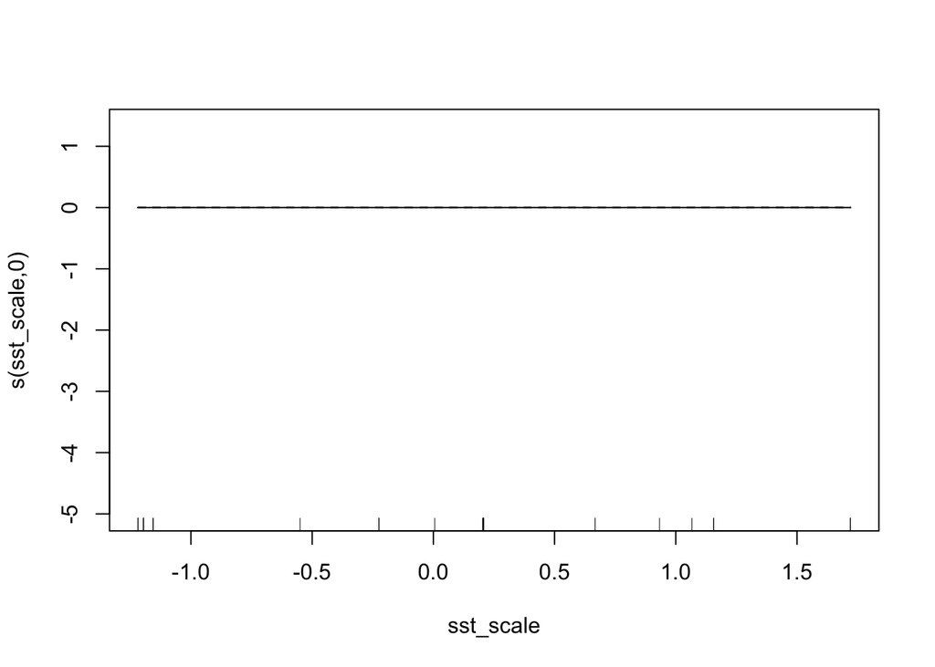

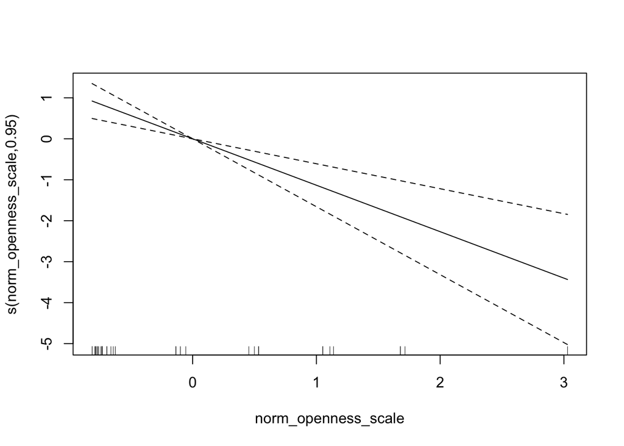

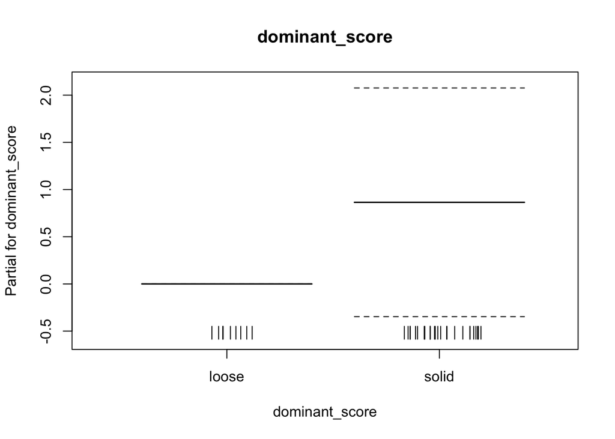

```
##
## Family: gaussian
## Link function: identity
##
## Formula:
## log(snail_dens + 0.01) ~ s(sst_scale) + s(norm_openness_scale) +
##     dominant_score
##
## Parametric coefficients:
##                     Estimate Std. Error t value Pr(>|t|)
## (Intercept)          -1.5842     0.5170  -3.064   0.0044 **
## dominant_scoresolid   0.8647     0.6057   1.428   0.1630
## ---
## Signif. codes:  0 '***' 0.001 '**' 0.01 '*' 0.05 '.' 0.1 ' ' 1
##
## Approximate significance of smooth terms:
##                              edf Ref.df     F  p-value
## s(sst_scale)           2.024e-05      9 0.000 0.745531
## s(norm_openness_scale) 9.493e-01      9 2.078 0.000101 ***
## ---
## Signif. codes:  0 '***' 0.001 '**' 0.01 '*' 0.05 '.' 0.1 ' ' 1
##
## R-sq.(adj) =  0.343   Deviance explained = 38.1%
## -REML = 64.571  Scale est. = 2.2703    n = 35
```

##### Testing the residuals for autocorrelation

To test each of our models for spatial autocorrelation we conducted a Moran’s I test on the model residuals. To ensure even better confidence in the results we used both a nearest neighbour weight matrix method and an inverse distance weight matrix for the Moran’s I weight matrix.

```
##
##  Moran I test under randomisation
##
## data:  residuals_ecology_snail_mod
## weights: lw
## n reduced by no-neighbour observations
##
## Moran I statistic standard deviate = 1.0542, p-value = 0.2918
## alternative hypothesis: two.sided
## sample estimates:
## Moran I statistic       Expectation          Variance
##        0.28283621       -0.05882353        0.10502790
```

```
##
##  Moran I test under randomisation
##
## data:  residuals_ecology_snail_mod
## weights: lw_inverse
##
## Moran I statistic standard deviate = 1.9113, p-value = 0.05597
## alternative hypothesis: two.sided
## sample estimates:
## Moran I statistic       Expectation          Variance
##        0.29654949       -0.02941176        0.02908670
```

No autocorrelation for both methods.

##### Testing the model for concurvity

```
## $worst
##                                para s(sst_scale) s(norm_openness_scale)
## para                   1.000000e+00 4.176841e-24           1.365142e-17
## s(sst_scale)           4.173961e-24 1.000000e+00           9.527043e-01
## s(norm_openness_scale) 1.365141e-17 9.527043e-01           1.000000e+00
##
## $observed
##                                para s(sst_scale) s(norm_openness_scale)
## para                   1.000000e+00 1.283340e-30           9.533786e-34
## s(sst_scale)           4.173961e-24 1.000000e+00           4.675591e-01
## s(norm_openness_scale) 1.365141e-17 4.344995e-01           1.000000e+00
##
## $estimate
##                                para s(sst_scale) s(norm_openness_scale)
## para                   1.000000e+00 9.168891e-28           2.363901e-21
## s(sst_scale)           4.173961e-24 1.000000e+00           4.716431e-01
## s(norm_openness_scale) 1.365141e-17 4.621752e-01           1.000000e+00
```

```
##              para s(sst_scale) s(norm_openness_scale)
## worst    0.864154    0.9530676              0.9529587
## observed 0.864154    0.4361814              0.5114618
## estimate 0.864154    0.4931624              0.5009083
```

Temperature and openness seem to be somewhat concurve. Temp having no impact on the model (being removed by select).

#### Model 2: Ecology model on the snail counts with temperature, openness, and bottom type (linear openness)

```r
#As the openness in the previous model was shown to be linearly related we
#redid the model with it fitted as a linear predictor
ecology_snail_mod_linear <- gam(log(snail_dens + 0.01) ~ s(sst_scale)+
                               norm_openness_scale+
                           dominant_score,
                             data = env_mod_data_hon,
                             family = gaussian(link = "identity"),
                             method = "REML",
                             select = TRUE)
```

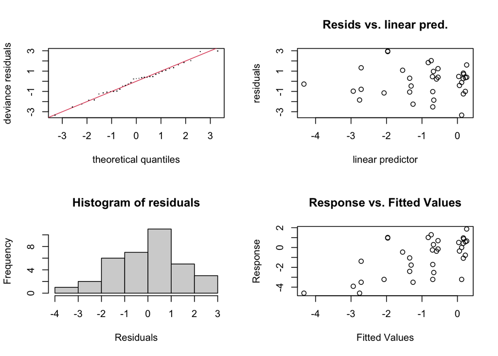

```
##
## Method: REML   Optimizer: outer newton
## full convergence after 10 iterations.
## Gradient range [-1.740135e-05,5.557029e-06]
## (score 62.97458 & scale 2.270256).
## Hessian positive definite, eigenvalue range [7.261404e-07,15.99999].
## Model rank =  12 / 12
##
## Basis dimension (k) checking results. Low p-value (k-index<1) may
## indicate that k is too low, especially if edf is close to k'.
##
##                    k'      edf k-index p-value
## s(sst_scale) 9.00e+00 4.74e-05    0.93    0.23
```

```
##
##  Shapiro-Wilk normality test
##
## data:  ecology_snail_mod_linear$residuals
## W = 0.98751, p-value = 0.9542
```

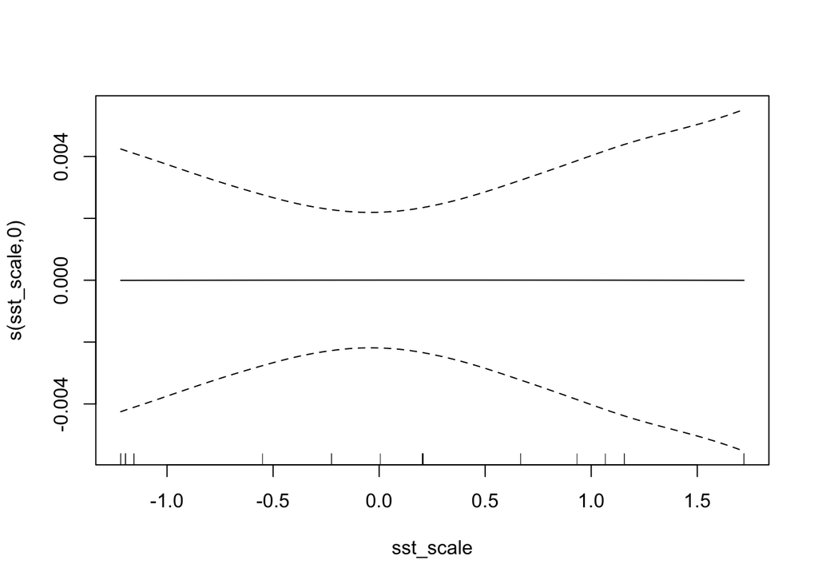

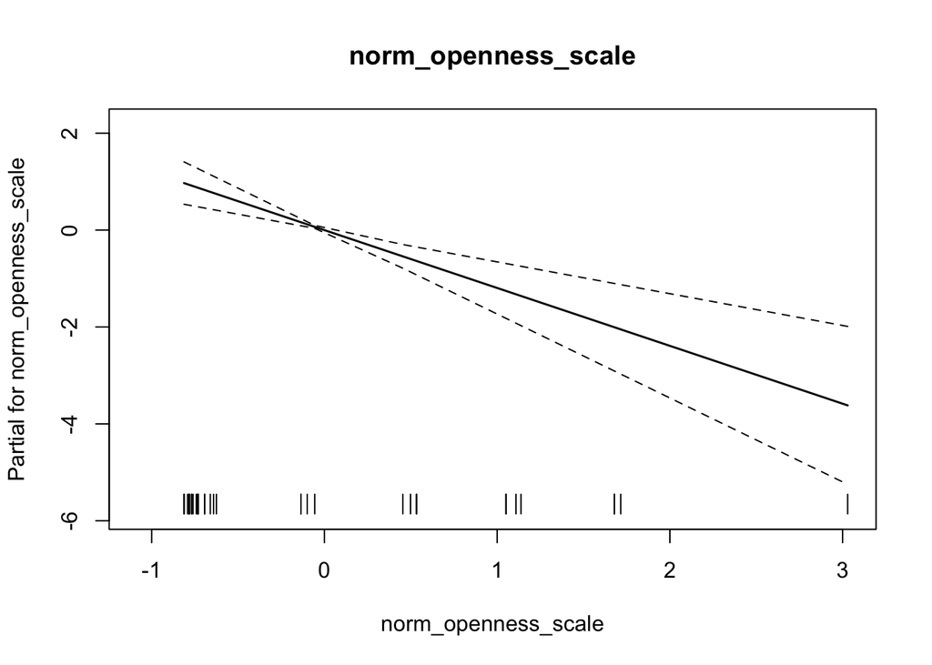

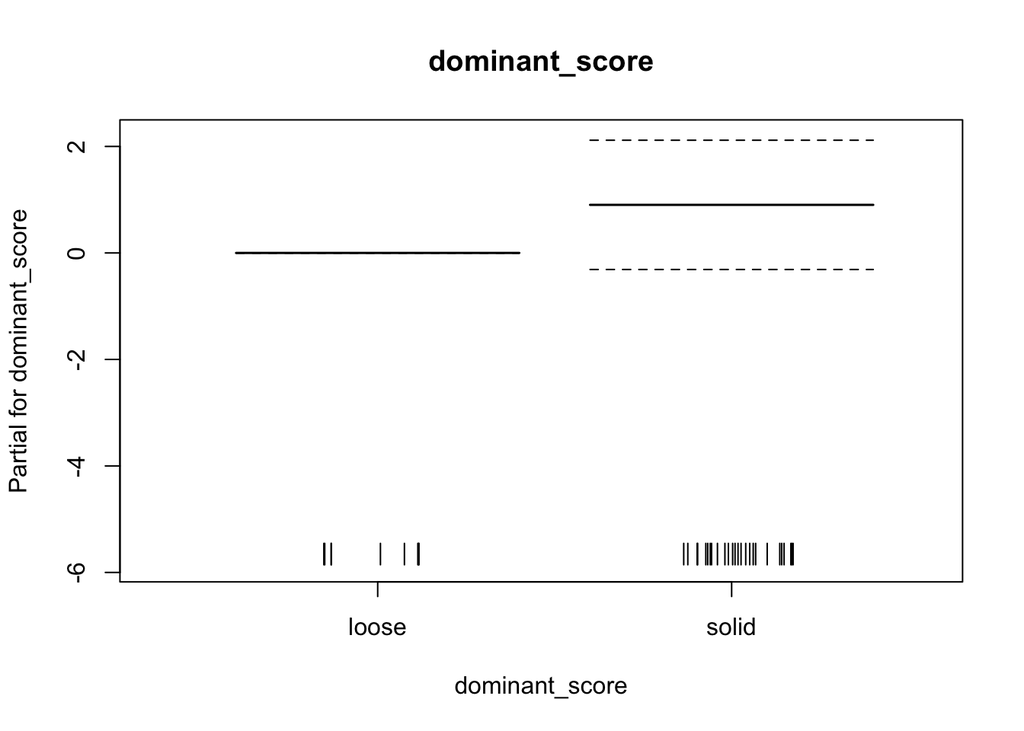

```
##
## Family: gaussian
## Link function: identity
##
## Formula:
## log(snail_dens + 0.01) ~ s(sst_scale) + norm_openness_scale +
##     dominant_score
##
## Parametric coefficients:
##                     Estimate Std. Error t value Pr(>|t|)
## (Intercept)          -1.6126     0.5178  -3.114 0.003870 **
## norm_openness_scale  -1.1945     0.2691  -4.439 0.000101 ***
## dominant_scoresolid   0.9029     0.6069   1.488 0.146595
## ---
## Signif. codes:  0 '***' 0.001 '**' 0.01 '*' 0.05 '.' 0.1 ' ' 1
##
## Approximate significance of smooth terms:
##                    edf Ref.df F p-value
## s(sst_scale) 4.737e-05      9 0   0.784
##
## R-sq.(adj) =  0.343   Deviance explained = 38.2%
## -REML = 62.975  Scale est. = 2.2703    n = 35
```

##### Testing the residuals for autocorrelation

```
##
##  Moran I test under randomisation
##
## data:  residuals_ecology_snail_mod_linear
## weights: lw
## n reduced by no-neighbour observations
##
## Moran I statistic standard deviate = 1.0933, p-value = 0.2743
## alternative hypothesis: two.sided
## sample estimates:
## Moran I statistic       Expectation          Variance
##        0.29408282       -0.05882353        0.10419893
```

```
##
##  Moran I test under randomisation
##
## data:  residuals_ecology_snail_mod_linear
## weights: lw_inverse
##
## Moran I statistic standard deviate = 1.9598, p-value = 0.05002
## alternative hypothesis: two.sided
## sample estimates:
## Moran I statistic       Expectation          Variance
##        0.30424482       -0.02941176        0.02898616
```

No autocorrelation for both methods.

##### Testing the model for concurvity

```
## $worst
##                      para s(sst_scale)
## para         1.000000e+00 4.176841e-24
## s(sst_scale) 4.162202e-24 1.000000e+00
##
## $observed
##                      para s(sst_scale)
## para         1.000000e+00 4.367291e-31
## s(sst_scale) 4.162202e-24 1.000000e+00
##
## $estimate
##                      para s(sst_scale)
## para         1.000000e+00 9.168891e-28
## s(sst_scale) 4.162202e-24 1.000000e+00
```

```
##               para s(sst_scale)
## worst    0.8032291    0.4731311
## observed 0.8032291    0.1134194
## estimate 0.8032291    0.1317249
```

Concurvity seems to be improved when having openness as a linear term.

#### Model 3: Ecology model on the snail counts with temperature, openness, and bottom type and random effect (linear openness)

```r
#To see if a random effect of region was important to add we tried a model with
#this included
ecology_snail_mod_linear_re <- gam(log(snail_dens + 0.01) ~ s(sst_scale)+
                               norm_openness_scale +
                           dominant_score+
                                s(region1, bs = "re"),
                             data = env_mod_data_hon,
                             family = gaussian(link = "identity"),
                             method = "REML",
                             select = TRUE)
```

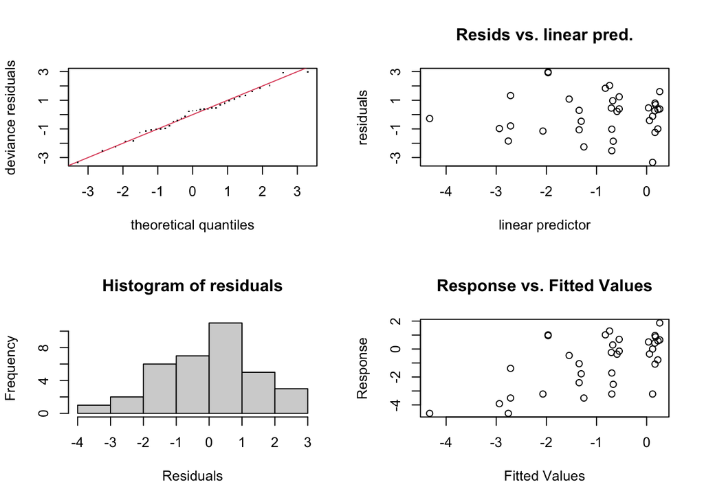

```
##
## Method: REML   Optimizer: outer newton
## full convergence after 11 iterations.
## Gradient range [-8.523478e-06,1.928063e-05]
## (score 62.97457 & scale 2.270254).
## Hessian positive definite, eigenvalue range [6.603573e-07,15.99998].
## Model rank =  16 / 16
##
## Basis dimension (k) checking results. Low p-value (k-index<1) may
## indicate that k is too low, especially if edf is close to k'.
##
##                    k'      edf k-index p-value
## s(sst_scale) 9.00e+00 2.38e-05    0.93    0.31
## s(region1)   4.00e+00 4.21e-05      NA      NA
```

```
##
##  Shapiro-Wilk normality test
##
## data:  ecology_snail_mod_linear_re$residuals
## W = 0.98751, p-value = 0.9542
```

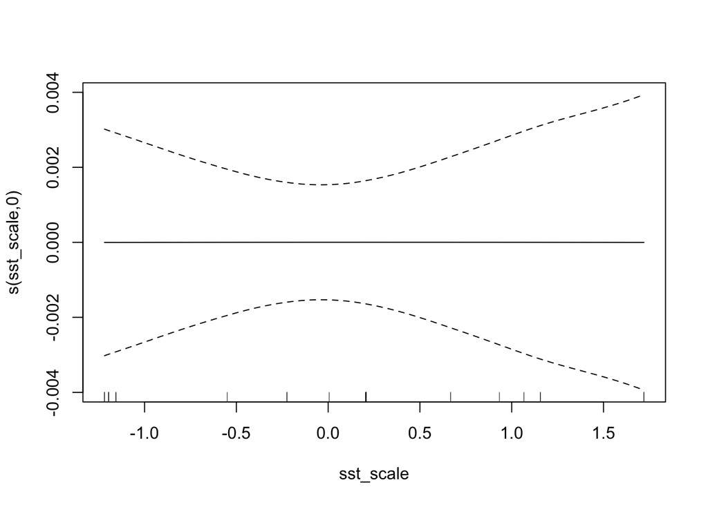